# Practice Materials for Exam 1

Ranadeep Daw

2024-09-07

## Note

### **I am not filling in the hypotheses and other text details. You must do it in your exams.**

## Output Analyzing

#### 1. Look at the following output of a test in $\texttt{R}$.

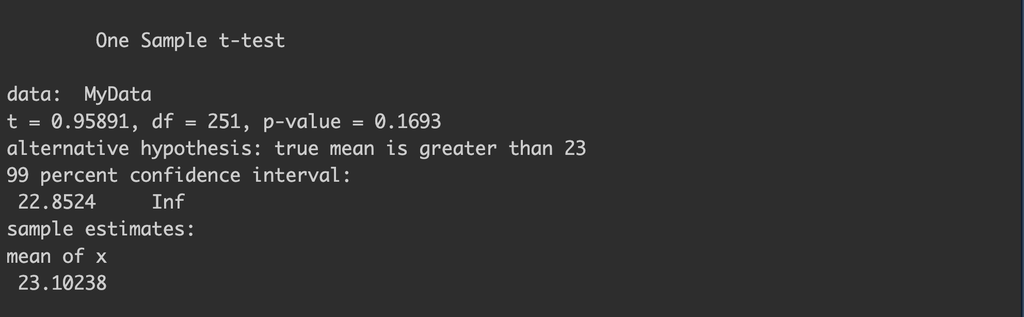

##### A. What test am I performing here?

##### B. How many observations are there in the data?

##### C. What is the significance ($\alpha$) of the test?

##### D. Write down the null and alternate hypotheses.

##### E. What is the sample estimate of the parameter being tested here?

##### F. What is the conclusion of the test?

##### G. What is the associated confidence interval for the population parameter that is being tested?

#### 2. Now do the same for the following test. Also can you tell what the confidence interval is about?

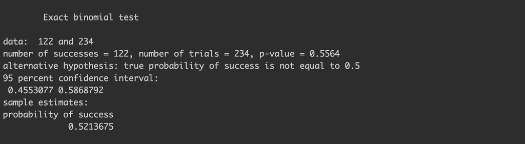

## Conceptual Questions

#### 1. For a normal distribution with mean $10$ and variance $25$, what are the 3 quartiles and IQR?

#### 2. Suppose that for a normal distribution, the first and third quartiles are $10$ and $25$. What are the mean, variance, median, and IQR?

#### 3. For a one-sample t-test, match the alternate hypotheses, rejection regions, and confidence intervals. Here $T$ is the usual statistic for a one sample $t$-test for mean, and $t_{\alpha; \nu}$ is the usual notation for critical score from a student’s $t$ distribution.

| Alternate Hypothesis | Rejection Region | Confidence Interval |
| --- | --- | --- |
| 1. $H_1: \mu > \mu_0$ | A. $\|T\| > t_{\alpha/2, n-1}$ | I. $\left(-\infty, \bar{x} - t_{\alpha, n-1} \cdot \frac{s}{\sqrt{n}} \right)$ |
| 2. $H_1: \mu < \mu_0$ | B. $T > t_{\alpha, n-1}$ | II. $\left(\bar{x} - t_{\alpha/2, n-1} \cdot \frac{s}{\sqrt{n}}, \bar{x} + t_{\alpha/2, n-1} \cdot \frac{s}{\sqrt{n}} \right)$ |
| 3. $H_1: \mu \neq \mu_0$ | C. $T < -t_{\alpha, n-1}$ | III. $\left(\bar{x} + t_{\alpha, n-1} \cdot \frac{s}{\sqrt{n}}, \infty \right)$ |

#### 4. What is the difference between a parametric estimation method and a nonparametric statistical method?

#### 5. Is it a population or sample?

1. A survey of 200 households’ monthly electricity usage over Pensacola.
2. I want to study UWF students’ average blood pressure. I collect data on all the students from UWF.
3. I want to study the average blood pressure of the Florida state university students. I collect data on all the students from UWF.
4. The annual median income over the counties from American Community survey data.
5. Daily temperature data over the Gulf of Mexico for 3 years.

## Data summarization

### Here is a data on mean arterial pressure (MAP) by sex:

| MAP | 82 | 84 | 85 | 88 | 92 | 93 | 94 | 95 | 98 | 100 | 102 | 107 | 110 | 116 | 116 |
| --- | --- | --- | --- | --- | --- | --- | --- | --- | --- | --- | --- | --- | --- | --- | --- |
| Sex | M | F | F | M | M | F | F | M | M | F | M | F | M | F | M |

#### 1. Calculate the mean, median, variance, standard deviation, and range of MAP.

#### 2. Calculate the quartiles and the IQR of MAP. Draw a boxplot of MAP.

#### 3. Calculate the upper and lower fence values for MAP. Checking by the fence values, are there evidence of outliers?

#### 4. Calculate the mean and variance only for $\texttt{Sex = M}$.

## Estimation and one sample test

### Use the $\texttt{BodyFat}$ data[^1] data from HW1. Download it using:

```r
bodyfat_data = read.csv(url("https://hbiostat.org/data/repo/bodyfat.csv"))
```

#### 1. Can you reasonably estimate the population mean, variance, and the first quartile of the $\texttt{Density}$ (column name = *Density*)variable under normality assumption? Please justify your answer.

#### 2. What are your reasonable estimates for the same under nonparametric method (or without a parametric assumption)? Please justify your answer.

#### 3. Perform a one sample $t$ test to test if the average biceps circumference (column name = *Biceps*) is less than 30.

#### 4. We are interested in median biceps circumference and we want to test if it is greater than $33.8$. How would you test?

## Two sample test

### Load the following data about pulse rates before and after excercize from http://www.statsci.org/data/oz/ms212.txt

```r
pulse_data = read.table(url("http://www.statsci.org/data/oz/ms212.txt"), skip = 1)
colnames(pulse_data) =   c("Height","Weight"      ,"Age"    ,"Gender"     ,"Smokes"   ,"Alcohol"      ,"Exercise"  ,"Ran"  ,"Pulse1"     ,"Pulse2"    ,"Year"   )
pulse_data = pulse_data[complete.cases(pulse_data), ]
```

#### 1. Do a parametric test if there is a difference on the average pulse rate (column name = **Pulse1**) based on gender (column name = **Gender**). Take $\alpha = 0.05$.

#### 2. Do a non-parametric test if there is a difference on the average pulse rate (column name = **Pulse1**) based on gender (column name = **Gender**). Take $\alpha = 0.05$.

#### 3. Do a parametric test on the assumption that pulse rate after excercize (column name = **Pulse2**) is higher than pulse rate before excercize (column name = **Pulse1**). Take $\alpha = 0.05$.

#### 2. Do a non-parametric test on the assumption that pulse rate after excercize (column name = **Pulse2**) is higher than pulse rate before excercize (column name = **Pulse1**). Take $\alpha = 0.05$.

## Some resources

1. One and two sample tests https://intro2r.com/one-and-two-sample-tests.html
2. Nonparametric statistics: https://bookdown.org/thomas_pernet/Tuto/non-parametric-tests.html
3. Hypothesis testing and basic R: https://bookdown.org/speegled/foundations-of-statistics/HTCI.html
[^1]: https://hbiostat.org/data/